# 2ª Atividade de Aprendizado de Máquina

# Redução de Dimensionalidade

## Programa de Pós-graduação em Ciência da Computação - PPGCC/UECE

## **Resumo**

Neste trabalho são realizados experimentos de redução de dimensionalidade com a base de dados *UCI Machine Learning Repository: Wine Quality Data Set*. Esse conjunto apresenta informações relacionadas à qualidade de vinhos brancos e tintos. Na análise, optou-se exclusivamente pelo subconjunto dos vinhos tintos. Nos testes implementou-se o algoritmo PCA, com o cálculo da matriz de covariância, dos autovalores, dos autovetores e da variância explicada. Além disso, foram realizados experimentos em três imagens, aplicando-se a redução de dimensionalidade em cada uma delas. Por fim, foi realizado um comparativo com outro algoritmo de redução de dimensionalidade, o LDA. Trabalho inserido no âmbito da disciplina de Aprendizado de Máquina, professora Ana Luiza Bessa, Programa de Pós-graduação em Ciência da Computação, Universidade Estadual do Ceará.

# **1. Introdução**

A denominada redução de dimensionalidade é técnica comumente aplicada em problemas que apresentam elevado número de atributos. É o caso clássico de aplicações de reconhecimento/processamento de imagens. O objetivo da técnica é representar o conjunto de dados com um menor número de variáveis, de forma a reduzir os custos computacionais e melhorar o desempenho do modelo induzido. Tal necessidade advém do problema da "maldição da dimensionalidade", que se trata justamente do aumento exponencial da variedade de objetos necessários ao treinamento a partir do número excessivo de variáveis independentes.

O foco deste trabalho é um algoritmo de redução de dimensionalidade bastante popular, o *Principal Component Analysis*, mais conhecido pela sigla PCA. Sua implementação baseia-se na ideia de obter a correlação estatísticas das observações, reduzindo a dimensionalidade do conjunto de dados original por meio da combinação das variáveis originais.

Conforme comandos das questões, buscou-se a implementação do PCA por meio do cálculo da matriz de covariância, dos autovalores, dos autovetores e da variância explicada. Além disso, foram realizados experimentos em três imagens, aplicando-se a redução de dimensionalidade em cada uma delas. Por fim, foi realizado um comparativo com outro algoritmo de redução de dimensionalidade, o LDA.

# **2. Redução de Dimensionalidade**

Redução de dimensionalidade é o processo por meio do qual se busca a transformação de um espaço para outro com menor dimensão, de forma a manter o valor intríseco dos dados o mais próximo possível do original.

As técnicas para reduzir a dimensionalidade de modelos podem ser divididas em duas grandes categorias, a saber: agregação e seleção de atributos. Na primeira, ocorre a substituição de atributos, condensando-se mais de um deles em uma espécie de "variável resumo" que, com certo nível de perda, representa aquele conjunto de dados. Já a seleção de atributos se ocupa em identificar o sub-conjunto ótimo das variáveis independentes, de forma a eliminar *features* redundantes ou desnecessárias.

A redução de dimensionalidade é importante para o aprendizado de máquina porque permite tornar "tratáveis" problemas envolvendo um grande espaço vetorial. Ou seja, torna mais viável computacionalmente a execução de um modelo quando este é substituído por outro com um menor número de variáveis.

# **3. PCA (Principal Component Analysis)**

O PCA é um método clássico de redução de dimensionalidade que provê uma sequência de melhores aproximações lineares do espaço de variáveis original. Assim, transforma um número de variáveis possivelmente correlacionadas em um novo sistema de coordenadas com um número menor de variáveis não correlacionadas chamadas componentes principais, enquanto mantém o tanto quanto possível da variabilidade nos dados originais.

Para tal, calcula-se a matriz de correlação do conjunto de dados original. A partir dela, são decompostos os autovetores e os autovalores. Os autovetores dão as direções da nova base na qual a matriz de covariância é diagonal. Já os autovalores correspondem ao valor escalar que os autovetores correspondente são escalonados na transformação linear.

Os autovalores dão a variância explicada do autovetor correspondente. Ordenando-se os autovetores em ordem descrescente de acordo com os autovalores, pode-se ordenar as components principais por ordem de importância, e eventualmente remover as associadas com uma variância pequena.

# **4. Variância Explicada**

O objetivo do PCA é obter a maior variância por meio do menor número de dimensões. Após a decomposição da matriz de correlação, tem-se na soma do autovalores ordenados a variância total dos autovetores correspondentes.

Ou seja, variância explicada refere-se à medida da proporção na qual um modelo matemático contabiliza a variância de um dado conjunto de dados.

Conforme essa proporção se aproxima de 100%, tem-se a possibilidade de selecionar as melhores dimensões, descartando-se as demais.

# **5. Método de Redução de Dimensionalidade para Comparação**

Para este trabalho, optou-se por se utilizar o LDA, Linear Discriminant Analysis, para fins de comparação com o PCA. O LDA é definido, na maioria das vezes, como um algoritmo de extração de *features* supervisionado. Todavia, alguns autores sustentam que o LDA pode ser utilizado como um classificador linear.

Assim como o PCA, o LDA procura combinações lineares de variáveis que melhor explicam os dados. O LDA tenta explicitamente modelar a diferença entre as classes de dados. O PCA, por outro lado, não leva em consideração nenhuma diferença de classe, obtendo as combinações de recursos com base em diferenças em vez de semelhanças.

O LDA sempre gera um número de *features* menor que o número de classes. Logo, em problemas de classificação binária o método gera apenas uma variável, independentemente do número de dimensões do *dataset* original.

# **6. Metodologia**

Para implementação dos experimentos, optou-se pela linguagem Python. Assim, foram utilizadas as bibliotecas bases da linguagem para o algoritmo PCA e o scikit-learn para comparação com o LDA.

# **7. Resultados**

Carregando a base de dados e exibindo alguma informações básicas sobre o *dataset*:

```python
import ds_utils as util
dsWineRed = util.getDSWine_RED()
dsWineRed.info();
```

```
<class 'pandas.core.frame.DataFrame'>
RangeIndex: 1599 entries, 0 to 1598
Data columns (total 12 columns):
 #   Column                Non-Null Count  Dtype
---  ------                --------------  -----
 0   fixed acidity         1599 non-null   float64
 1   volatile acidity      1599 non-null   float64
 2   citric acid           1599 non-null   float64
 3   residual sugar        1599 non-null   float64
 4   chlorides             1599 non-null   float64
 5   free sulfur dioxide   1599 non-null   float64
 6   total sulfur dioxide  1599 non-null   float64
 7   density               1599 non-null   float64
 8   pH                    1599 non-null   float64
 9   sulphates             1599 non-null   float64
 10  alcohol               1599 non-null   float64
 11  quality               1599 non-null   int64
dtypes: float64(11), int64(1)
memory usage: 150.0 KB
```

```python
dsWineRed.head()
```

|  | fixed acidity | volatile acidity | citric acid | residual sugar | chlorides | free sulfur dioxide | total sulfur dioxide | density | pH | sulphates | alcohol | quality |
| --- | --- | --- | --- | --- | --- | --- | --- | --- | --- | --- | --- | --- |
| 0 | 7.4 | 0.70 | 0.00 | 1.9 | 0.076 | 11.0 | 34.0 | 0.9978 | 3.51 | 0.56 | 9.4 | 5 |
| 1 | 7.8 | 0.88 | 0.00 | 2.6 | 0.098 | 25.0 | 67.0 | 0.9968 | 3.20 | 0.68 | 9.8 | 5 |
| 2 | 7.8 | 0.76 | 0.04 | 2.3 | 0.092 | 15.0 | 54.0 | 0.9970 | 3.26 | 0.65 | 9.8 | 5 |
| 3 | 11.2 | 0.28 | 0.56 | 1.9 | 0.075 | 17.0 | 60.0 | 0.9980 | 3.16 | 0.58 | 9.8 | 6 |
| 4 | 7.4 | 0.70 | 0.00 | 1.9 | 0.076 | 11.0 | 34.0 | 0.9978 | 3.51 | 0.56 | 9.4 | 5 |

```python
dsWineRed.describe()
```

|  | fixed acidity | volatile acidity | citric acid | residual sugar | chlorides | free sulfur dioxide | total sulfur dioxide | density | pH | sulphates | alcohol | quality |
| --- | --- | --- | --- | --- | --- | --- | --- | --- | --- | --- | --- | --- |
| count | 1599.000000 | 1599.000000 | 1599.000000 | 1599.000000 | 1599.000000 | 1599.000000 | 1599.000000 | 1599.000000 | 1599.000000 | 1599.000000 | 1599.000000 | 1599.000000 |
| mean | 8.319637 | 0.527821 | 0.270976 | 2.538806 | 0.087467 | 15.874922 | 46.467792 | 0.996747 | 3.311113 | 0.658149 | 10.422983 | 5.636023 |
| std | 1.741096 | 0.179060 | 0.194801 | 1.409928 | 0.047065 | 10.460157 | 32.895324 | 0.001887 | 0.154386 | 0.169507 | 1.065668 | 0.807569 |
| min | 4.600000 | 0.120000 | 0.000000 | 0.900000 | 0.012000 | 1.000000 | 6.000000 | 0.990070 | 2.740000 | 0.330000 | 8.400000 | 3.000000 |
| 25% | 7.100000 | 0.390000 | 0.090000 | 1.900000 | 0.070000 | 7.000000 | 22.000000 | 0.995600 | 3.210000 | 0.550000 | 9.500000 | 5.000000 |
| 50% | 7.900000 | 0.520000 | 0.260000 | 2.200000 | 0.079000 | 14.000000 | 38.000000 | 0.996750 | 3.310000 | 0.620000 | 10.200000 | 6.000000 |
| 75% | 9.200000 | 0.640000 | 0.420000 | 2.600000 | 0.090000 | 21.000000 | 62.000000 | 0.997835 | 3.400000 | 0.730000 | 11.100000 | 6.000000 |
| max | 15.900000 | 1.580000 | 1.000000 | 15.500000 | 0.611000 | 72.000000 | 289.000000 | 1.003690 | 4.010000 | 2.000000 | 14.900000 | 8.000000 |

### 1. Para a base de dados escolhida na Atividade 1, aplique redução de dimensionalidade utilizando a técnica PCA (Principal Component Analysis), e apresente:

### • Matriz de covariância

### • Autovalores da matriz de covariância

### • Autovetores da matriz de covariância

### • Variância explicada de acordo com a quantidade de autovetores

```python
import numpy as np
#matriz de covariância
#separando as variáveis independentes e a variável dependente
X = dsWineRed.drop('quality', axis=1)
X
```

|  | fixed acidity | volatile acidity | citric acid | residual sugar | chlorides | free sulfur dioxide | total sulfur dioxide | density | pH | sulphates | alcohol |
| --- | --- | --- | --- | --- | --- | --- | --- | --- | --- | --- | --- |
| 0 | 7.4 | 0.700 | 0.00 | 1.9 | 0.076 | 11.0 | 34.0 | 0.99780 | 3.51 | 0.56 | 9.4 |
| 1 | 7.8 | 0.880 | 0.00 | 2.6 | 0.098 | 25.0 | 67.0 | 0.99680 | 3.20 | 0.68 | 9.8 |
| 2 | 7.8 | 0.760 | 0.04 | 2.3 | 0.092 | 15.0 | 54.0 | 0.99700 | 3.26 | 0.65 | 9.8 |
| 3 | 11.2 | 0.280 | 0.56 | 1.9 | 0.075 | 17.0 | 60.0 | 0.99800 | 3.16 | 0.58 | 9.8 |
| 4 | 7.4 | 0.700 | 0.00 | 1.9 | 0.076 | 11.0 | 34.0 | 0.99780 | 3.51 | 0.56 | 9.4 |
| ... | ... | ... | ... | ... | ... | ... | ... | ... | ... | ... | ... |
| 1594 | 6.2 | 0.600 | 0.08 | 2.0 | 0.090 | 32.0 | 44.0 | 0.99490 | 3.45 | 0.58 | 10.5 |
| 1595 | 5.9 | 0.550 | 0.10 | 2.2 | 0.062 | 39.0 | 51.0 | 0.99512 | 3.52 | 0.76 | 11.2 |
| 1596 | 6.3 | 0.510 | 0.13 | 2.3 | 0.076 | 29.0 | 40.0 | 0.99574 | 3.42 | 0.75 | 11.0 |
| 1597 | 5.9 | 0.645 | 0.12 | 2.0 | 0.075 | 32.0 | 44.0 | 0.99547 | 3.57 | 0.71 | 10.2 |
| 1598 | 6.0 | 0.310 | 0.47 | 3.6 | 0.067 | 18.0 | 42.0 | 0.99549 | 3.39 | 0.66 | 11.0 |

1599 rows × 11 columns

```python
y = dsWineRed['quality']
y
```

```
0       5
1       5
2       5
3       6
4       5
       ..
1594    5
1595    6
1596    6
1597    5
1598    6
Name: quality, Length: 1599, dtype: int64
```

```python
#calculando as médias por coluna de X
X_mean = np.mean(X, axis=0)
X_mean
```

```
fixed acidity            8.319637
volatile acidity         0.527821
citric acid              0.270976
residual sugar           2.538806
chlorides                0.087467
free sulfur dioxide     15.874922
total sulfur dioxide    46.467792
density                  0.996747
pH                       3.311113
sulphates                0.658149
alcohol                 10.422983
dtype: float64
```

```python
#gerando matriz auxiliar para o cálculo da Matriz de Covariância
M_aux = X - X_mean
M_aux
```

|  | fixed acidity | volatile acidity | citric acid | residual sugar | chlorides | free sulfur dioxide | total sulfur dioxide | density | pH | sulphates | alcohol |
| --- | --- | --- | --- | --- | --- | --- | --- | --- | --- | --- | --- |
| 0 | -0.919637 | 0.172179 | -0.270976 | -0.638806 | -0.011467 | -4.874922 | -12.467792 | 0.001053 | 0.198887 | -0.098149 | -1.022983 |
| 1 | -0.519637 | 0.352179 | -0.270976 | 0.061194 | 0.010533 | 9.125078 | 20.532208 | 0.000053 | -0.111113 | 0.021851 | -0.622983 |
| 2 | -0.519637 | 0.232179 | -0.230976 | -0.238806 | 0.004533 | -0.874922 | 7.532208 | 0.000253 | -0.051113 | -0.008149 | -0.622983 |
| 3 | 2.880363 | -0.247821 | 0.289024 | -0.638806 | -0.012467 | 1.125078 | 13.532208 | 0.001253 | -0.151113 | -0.078149 | -0.622983 |
| 4 | -0.919637 | 0.172179 | -0.270976 | -0.638806 | -0.011467 | -4.874922 | -12.467792 | 0.001053 | 0.198887 | -0.098149 | -1.022983 |
| ... | ... | ... | ... | ... | ... | ... | ... | ... | ... | ... | ... |
| 1594 | -2.119637 | 0.072179 | -0.190976 | -0.538806 | 0.002533 | 16.125078 | -2.467792 | -0.001847 | 0.138887 | -0.078149 | 0.077017 |
| 1595 | -2.419637 | 0.022179 | -0.170976 | -0.338806 | -0.025467 | 23.125078 | 4.532208 | -0.001627 | 0.208887 | 0.101851 | 0.777017 |
| 1596 | -2.019637 | -0.017821 | -0.140976 | -0.238806 | -0.011467 | 13.125078 | -6.467792 | -0.001007 | 0.108887 | 0.091851 | 0.577017 |
| 1597 | -2.419637 | 0.117179 | -0.150976 | -0.538806 | -0.012467 | 16.125078 | -2.467792 | -0.001277 | 0.258887 | 0.051851 | -0.222983 |
| 1598 | -2.319637 | -0.217821 | 0.199024 | 1.061194 | -0.020467 | 2.125078 | -4.467792 | -0.001257 | 0.078887 | 0.001851 | 0.577017 |

1599 rows × 11 columns

```python
#calculando a Matriz de Covariância
M_cov = M_aux.T.dot(M_aux) / (X.shape[0] - 1)
M_cov
```

|  | fixed acidity | volatile acidity | citric acid | residual sugar | chlorides | free sulfur dioxide | total sulfur dioxide | density | pH | sulphates | alcohol |
| --- | --- | --- | --- | --- | --- | --- | --- | --- | --- | --- | --- |
| fixed acidity | 3.031416 | -0.079851 | 0.227820 | 0.281756 | 0.007679 | -2.800921 | -6.482346 | 0.002195 | -0.183586 | 0.054010 | -0.114421 |
| volatile acidity | -0.079851 | 0.032062 | -0.019272 | 0.000484 | 0.000517 | -0.019674 | 0.450426 | 0.000007 | 0.006495 | -0.007921 | -0.038600 |
| citric acid | 0.227820 | -0.019272 | 0.037947 | 0.039434 | 0.001869 | -0.124252 | 0.227697 | 0.000134 | -0.016298 | 0.010328 | 0.022815 |
| residual sugar | 0.281756 | 0.000484 | 0.039434 | 1.987897 | 0.003690 | 2.758611 | 9.416441 | 0.000945 | -0.018644 | 0.001321 | 0.063219 |
| chlorides | 0.007679 | 0.000517 | 0.001869 | 0.003690 | 0.002215 | 0.002738 | 0.073387 | 0.000018 | -0.001926 | 0.002962 | -0.011092 |
| free sulfur dioxide | -2.800921 | -0.019674 | -0.124252 | 2.758611 | 0.002738 | 109.414884 | 229.737521 | -0.000433 | 0.113653 | 0.091592 | -0.773698 |
| total sulfur dioxide | -6.482346 | 0.450426 | 0.227697 | 9.416441 | 0.073387 | 229.737521 | 1082.102373 | 0.004425 | -0.337699 | 0.239471 | -7.209298 |
| density | 0.002195 | 0.000007 | 0.000134 | 0.000945 | 0.000018 | -0.000433 | 0.004425 | 0.000004 | -0.000100 | 0.000048 | -0.000998 |
| pH | -0.183586 | 0.006495 | -0.016298 | -0.018644 | -0.001926 | 0.113653 | -0.337699 | -0.000100 | 0.023835 | -0.005146 | 0.033832 |
| sulphates | 0.054010 | -0.007921 | 0.010328 | 0.001321 | 0.002962 | 0.091592 | 0.239471 | 0.000048 | -0.005146 | 0.028733 | 0.016907 |
| alcohol | -0.114421 | -0.038600 | 0.022815 | 0.063219 | -0.011092 | -0.773698 | -7.209298 | -0.000998 | 0.033832 | 0.016907 | 1.135647 |

```python
#autovalores da matriz de covariância
# determinando auto-valores e auto-vetores
autoval, autovet = np.linalg.eig(M_cov)
autoval[:10] #mostrando os primeiros 10
```

```
array([1.13380708e+03, 5.79354108e+01, 3.10130228e+00, 1.81941532e+00,
       1.04634036e+00, 4.13967294e-02, 2.31926578e-02, 1.13464685e-02,
       1.00779841e-02, 1.45499755e-03])
```

```python
autovet[:10] #mostrando os primeiros 10
```

```
array([[ 6.13247431e-03, -2.38994985e-02, -9.53135980e-01,
        -2.65092214e-01,  9.81476468e-02,  7.93123729e-02,
         1.11415873e-02,  6.49066070e-02, -1.62056112e-02,
         1.11894679e-02, -9.42137146e-04],
       [-3.84465551e-04, -2.00966661e-03,  2.51315387e-02,
         7.27374987e-03, -4.11570558e-02,  6.89241790e-01,
         4.64366208e-01, -3.38841054e-01,  4.28631866e-01,
        -9.15867655e-02, -7.18832280e-04],
       [-1.70902595e-04, -3.03480788e-03, -7.37082746e-02,
        -9.83215158e-03,  4.14815020e-02, -5.04044257e-01,
        -2.05507873e-01, -3.27123399e-01,  7.60466107e-01,
        -1.05489073e-01, -5.84467646e-05],
       [-8.64894648e-03,  1.11348551e-02, -2.80913620e-01,
         9.43177990e-01, -1.76626862e-01, -5.76573957e-03,
         2.49458552e-03,  4.13432131e-03, -6.93128776e-03,
        -1.48602896e-03, -4.12747476e-04],
       [-6.37307290e-05, -2.36654751e-04, -2.94578815e-03,
        -6.45262673e-04, -9.47985067e-03, -5.70159846e-02,
         1.13948493e-01, -1.32518260e-01,  7.21971030e-02,
         9.80249498e-01, -1.81878311e-03],
       [-2.18857434e-01,  9.75265982e-01, -2.08968395e-02,
        -2.11894371e-02, -7.86843454e-03,  1.05989214e-03,
        -9.26191533e-05, -2.57435147e-03,  1.49867896e-03,
        -3.17589826e-04,  8.57545760e-06],
       [-9.75678369e-01, -2.18916841e-01,  1.52685886e-03,
        -3.97992967e-03,  1.03231630e-02,  6.14340167e-04,
        -2.30257301e-04,  1.21187727e-03, -6.57103967e-04,
         2.60239937e-04, -2.65414500e-06],
       [-3.72498542e-06, -2.49998510e-05, -7.76139600e-04,
         5.52088341e-05, -8.33972282e-04,  4.67157195e-04,
         1.59988536e-03,  4.10828148e-03,  2.83889045e-03,
         2.03252714e-03,  9.99983426e-01],
       [ 2.68008619e-04,  3.27182194e-03,  5.86305467e-02,
         2.05779719e-02,  1.26215966e-02,  1.42001678e-01,
        -1.02608661e-02,  8.59196803e-01,  4.78787810e-01,
         9.06452527e-02, -5.06831403e-03],
       [-2.23381730e-04,  6.18926046e-04, -1.75252442e-02,
        -7.19926307e-03,  2.35852364e-02, -4.88427356e-01,
         8.53721238e-01,  1.32919186e-01, -5.35682617e-02,
        -1.05566655e-01, -1.31065389e-03]])
```

```python
# ordenando em ordem descrecente
pares_de_autos = [
 (
 np.abs(autoval[i]),
 autovet[:,i]
 ) for i in range(len(autoval))
]
pares_de_autos.sort()
pares_de_autos.reverse()
```

```python
# calculando a variância explicada e a variância explicada cumulativa
total = sum(autoval)
var_exp = [
 (i / total)*100 for i in sorted(
 autoval, reverse=True
 )
]
cum_var_exp = np.cumsum(var_exp)
cum_var_exp[:10] #mostrando os primeiros 10
```

```
array([94.65769764, 99.4945281 , 99.75344528, 99.90534208, 99.99269748,
       99.99615355, 99.99808983, 99.9990371 , 99.99987848, 99.99999995])
```

```python
import pandas as pd
# visualizando as informações
x = [
 'PC %s' %i for i in range(
 1,len(autoval)+1
 )
]
df_temp = pd.DataFrame(
 {'auto-valores': autoval,
 'cum_var_exp':cum_var_exp,
 'var_exp':var_exp,
 'Componente':x}
)
df_temp
```

|  | auto-valores | cum_var_exp | var_exp | Componente |
| --- | --- | --- | --- | --- |
| 0 | 1.133807e+03 | 94.657698 | 9.465770e+01 | PC 1 |
| 1 | 5.793541e+01 | 99.494528 | 4.836830e+00 | PC 2 |
| 2 | 3.101302e+00 | 99.753445 | 2.589172e-01 | PC 3 |
| 3 | 1.819415e+00 | 99.905342 | 1.518968e-01 | PC 4 |
| 4 | 1.046340e+00 | 99.992697 | 8.735540e-02 | PC 5 |
| 5 | 4.139673e-02 | 99.996154 | 3.456072e-03 | PC 6 |
| 6 | 2.319266e-02 | 99.998090 | 1.936276e-03 | PC 7 |
| 7 | 1.134647e-02 | 99.999037 | 9.472781e-04 | PC 8 |
| 8 | 1.007798e-02 | 99.999878 | 8.413766e-04 | PC 9 |
| 9 | 1.454998e-03 | 100.000000 | 1.214728e-04 | PC 10 |
| 10 | 5.614827e-07 | 100.000000 | 4.687628e-08 | PC 11 |

### 2. Escolha três imagens de sua preferência e aplique redução de dimensionalidade a cada uma delas utilizando a técnica PCA (Principal Component Analysis). Para cada uma das imagens, apresente:

### • Matriz de covariância

### • Autovalores da matriz de covariância

### • Autovetores da matriz de covariância

### • Variância explicada de acordo com a quantidade de autovetores

### • A imagem original e algumas versões com diferentes quantidades de autovetores

```python
import matplotlib.pyplot as plt
import seaborn as sns
import cv2
```

```python
#funções utilitárias para plotagem das imagens
from sklearn.decomposition import PCA

def pca_with_var_exp(X, var_exp=0.99):
    pca = PCA(var_exp) # variância explicada de 0.99
    lower_dimension_data = pca.fit_transform(X)
    print(lower_dimension_data.shape)
    approximation = pca.inverse_transform(lower_dimension_data)
    return approximation

def plot_subplot(X, i):
    plt.subplot(3,2,i)
    plt.imshow(X, cmap="gray")
    plt.xticks([])
    plt.yticks([])

# visualizando aproximações
def show_imgs(img_1, img_2, img_3):
    plt.figure(figsize=(6,8))
    plot_subplot(X_img_gray, 1)
    plt.title("Original")
    plot_subplot(img_1, 2)
    plt.title("Var. Explicada de 99%")
    plot_subplot(X_img_gray, 3)
    plt.title("Original")
    plot_subplot(img_2, 4)
    plt.title("Var. Explicada de 75%")
    plot_subplot(X_img_gray, 5)
    plt.title("Original")
    plot_subplot(img_3, 6)
    plt.title("Var. Explicada de 50%")
    plt.tight_layout()
    plt.show()
```

```python
#lendo a imagem 01
X_img_gray = plt.imread('imgs\img01.jpg')
X_img_gray.shape
```

```
(728, 1000)
```

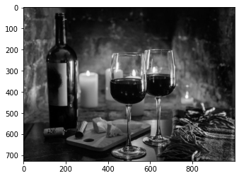

```python
plt.imshow(X_img_gray, cmap="gray");
```

```python
#calculando as médias por coluna de X (considerando X composto pelos pixels da imagem)
X_mean = np.mean(X_img_gray, axis=0)
X_mean[:10] #mostrando os primeiros 10
```

```
array([75.44230769, 74.79945055, 74.54258242, 74.60027473, 74.2032967 ,
       73.66895604, 72.94230769, 72.20741758, 72.01373626, 72.17445055])
```

```python
#gerando matriz auxiliar para o cálculo da Matriz de Covariância
M_aux = X_img_gray - X_mean
M_aux[:10] #mostrando os primeiros 10
```

```
array([[ 10.55769231,   9.20054945,   8.45741758, ...,  -4.7706044 ,
        -12.66071429, -18.13324176],
       [ 10.55769231,   9.20054945,   8.45741758, ...,  -3.7706044 ,
        -11.66071429, -17.13324176],
       [ 10.55769231,   9.20054945,   8.45741758, ...,  -1.7706044 ,
         -9.66071429, -14.13324176],
       ...,
       [  9.55769231,   9.20054945,   8.45741758, ...,   3.2293956 ,
         -4.66071429, -10.13324176],
       [ 14.55769231,  13.20054945,  11.45741758, ...,   0.2293956 ,
         -7.66071429, -10.13324176],
       [ 17.55769231,  16.20054945,  14.45741758, ...,   0.2293956 ,
         -5.66071429,  -8.13324176]])
```

```python
#calculando a Matriz de Covariância relativa à imagem
M_cov = M_aux.T.dot(M_aux) / (X_img_gray.shape[0] - 1)
M_cov[:10] #mostrando os primeiros 10
```

```
array([[1514.11771241, 1472.18923923, 1432.72254259, ..., -367.41971749,
        -401.90474553, -428.01499841],
       [1472.18923923, 1443.70938072, 1416.90538794, ..., -357.81223075,
        -390.12178228, -414.49043563],
       [1432.72254259, 1416.90538794, 1410.3860797 , ..., -351.76119496,
        -380.82528493, -402.86469119],
       ...,
       [1083.46796635, 1079.39241123, 1108.37561218, ..., -333.35125346,
        -348.93365592, -363.4802194 ],
       [1046.52073855, 1043.83081911, 1071.92788745, ..., -336.77263555,
        -350.88529181, -363.66208035],
       [1011.1098032 , 1008.87272322, 1033.59434943, ..., -342.0149474 ,
        -354.65049617, -365.82520179]])
```

```python
#autovalores da matriz de covariância
# determinando auto-valores e auto-vetores
autoval, autovet = np.linalg.eig(M_cov)
autoval[:10] #mostrando os primeiros 10
```

```
array([870372.14945459+0.j, 407823.25773279+0.j, 166858.75972121+0.j,
       114435.54735745+0.j,  66475.31290357+0.j,  52624.6585047 +0.j,
        44207.14151342+0.j,  33658.13845457+0.j,  33072.33247922+0.j,
        27242.07933376+0.j])
```

```python
autovet[:10] #mostrando os primeiros 10
```

```
array([[-0.00695092+0.j        , -0.03961221+0.j        ,
         0.04137587+0.j        , ...,  0.00302185+0.00122708j,
         0.01268853+0.j        , -0.00429257+0.j        ],
       [-0.00666886+0.j        , -0.03836892+0.j        ,
         0.04162525+0.j        , ..., -0.00114323+0.00062148j,
        -0.00350591+0.j        ,  0.00397616+0.j        ],
       [-0.00651453+0.j        , -0.03747471+0.j        ,
         0.04248193+0.j        , ..., -0.00221548+0.00093073j,
         0.00119642+0.j        ,  0.00265355+0.j        ],
       ...,
       [-0.00761922+0.j        , -0.02745473+0.j        ,
         0.04915017+0.j        , ..., -0.00428036+0.00341155j,
        -0.00761445+0.j        ,  0.01299525+0.j        ],
       [-0.00718816+0.j        , -0.02700955+0.j        ,
         0.05138686+0.j        , ...,  0.0095621 -0.00408932j,
         0.01267661+0.j        ,  0.00377503+0.j        ],
       [-0.00736387+0.j        , -0.02700333+0.j        ,
         0.05348907+0.j        , ..., -0.0065305 -0.00406288j,
        -0.00902267+0.j        ,  0.00953566+0.j        ]])
```

```python
#ordem decrescente
pares_de_autos = [
 (
 np.abs(autoval[i]),
 autovet[:,i]
 ) for i in range(len(autoval))
]
```

```python
# calculando a variância explicada e a variância explicada cumulativa
total = sum(autoval)
var_exp = [
 (i / total)*100 for i in sorted(
 autoval, reverse=True
 )
]
cum_var_exp = np.cumsum(var_exp)
cum_var_exp[:10] #mostrando os primeiros 10
```

```
array([40.09010351+0.j, 58.87479995+0.j, 66.56046056+0.j, 71.8314621 +0.j,
       74.89337323+0.j, 77.31731109+0.j, 79.35353075+0.j, 80.90385409+0.j,
       82.42719469+0.j, 83.68198872+0.j])
```

```python
# visualizando as informações
x = [
 'PC %s' %i for i in range(
 1,len(autoval)+1
 )
]
df_temp = pd.DataFrame(
 {'auto-valores': autoval,
 'cum_var_exp':cum_var_exp,
 'var_exp':var_exp,
 'Componente':x}
)
df_temp
```

|  | auto-valores | cum_var_exp | var_exp | Componente |
| --- | --- | --- | --- | --- |
| 0 | 8.703721e+05+0.000000e+00j | 40.090104+0.000000j | 4.009010e+01+0.000000e+00j | PC 1 |
| 1 | 4.078233e+05+0.000000e+00j | 58.874800+0.000000j | 1.878470e+01+0.000000e+00j | PC 2 |
| 2 | 1.668588e+05+0.000000e+00j | 66.560461+0.000000j | 7.685661e+00+0.000000e+00j | PC 3 |
| 3 | 1.144355e+05+0.000000e+00j | 71.831462+0.000000j | 5.271002e+00+0.000000e+00j | PC 4 |
| 4 | 6.647531e+04+0.000000e+00j | 74.893373+0.000000j | 3.061911e+00+0.000000e+00j | PC 5 |
| ... | ... | ... | ... | ... |
| 995 | 4.123428e-13-3.072642e-13j | 100.00000+0.00000j | -4.955237e-16+5.460538e-17j | PC 996 |
| 996 | 9.505296e-14+2.830805e-13j | 100.00000+0.00000j | -4.955237e-16-5.460538e-17j | PC 997 |
| 997 | 9.505296e-14-2.830805e-13j | 100.00000+0.00000j | -5.445998e-16+0.000000e+00j | PC 998 |
| 998 | 6.353111e-13+0.000000e+00j | 100.00000+0.00000j | -5.648732e-16+5.857598e-17j | PC 999 |
| 999 | -4.346809e-13+0.000000e+00j | 100.00000+0.00000j | -5.648732e-16-5.857598e-17j | PC 1000 |

1000 rows × 4 columns

```python
#selecionando os autovetores mais significativos
df_autovetores_mais_significativos = df_temp.loc[df_temp['cum_var_exp']<90]
df_autovetores_mais_significativos
```

|  | auto-valores | cum_var_exp | var_exp | Componente |
| --- | --- | --- | --- | --- |
| 0 | 870372.149455+0.000000j | 40.090104+0.000000j | 40.090104+0.000000j | PC 1 |
| 1 | 407823.257733+0.000000j | 58.874800+0.000000j | 18.784696+0.000000j | PC 2 |
| 2 | 166858.759721+0.000000j | 66.560461+0.000000j | 7.685661+0.000000j | PC 3 |
| 3 | 114435.547357+0.000000j | 71.831462+0.000000j | 5.271002+0.000000j | PC 4 |
| 4 | 66475.312904+0.000000j | 74.893373+0.000000j | 3.061911+0.000000j | PC 5 |
| 5 | 52624.658505+0.000000j | 77.317311+0.000000j | 2.423938+0.000000j | PC 6 |
| 6 | 44207.141513+0.000000j | 79.353531+0.000000j | 2.036220+0.000000j | PC 7 |
| 7 | 33658.138455+0.000000j | 80.903854+0.000000j | 1.550323+0.000000j | PC 8 |
| 8 | 33072.332479+0.000000j | 82.427195+0.000000j | 1.523341+0.000000j | PC 9 |
| 9 | 27242.079334+0.000000j | 83.681989+0.000000j | 1.254794+0.000000j | PC 10 |
| 10 | 23663.269957+0.000000j | 84.771940+0.000000j | 1.089951+0.000000j | PC 11 |
| 11 | 21627.388876+0.000000j | 85.768116+0.000000j | 0.996176+0.000000j | PC 12 |
| 12 | 19695.272267+0.000000j | 86.675298+0.000000j | 0.907181+0.000000j | PC 13 |
| 13 | 17977.458834+0.000000j | 87.503355+0.000000j | 0.828057+0.000000j | PC 14 |
| 14 | 14682.912275+0.000000j | 88.179663+0.000000j | 0.676308+0.000000j | PC 15 |
| 15 | 12782.300026+0.000000j | 88.768427+0.000000j | 0.588764+0.000000j | PC 16 |
| 16 | 12507.282797+0.000000j | 89.344523+0.000000j | 0.576096+0.000000j | PC 17 |
| 17 | 11401.878064+0.000000j | 89.869704+0.000000j | 0.525180+0.000000j | PC 18 |

```
(728, 96)
(728, 6)
(728, 2)
```

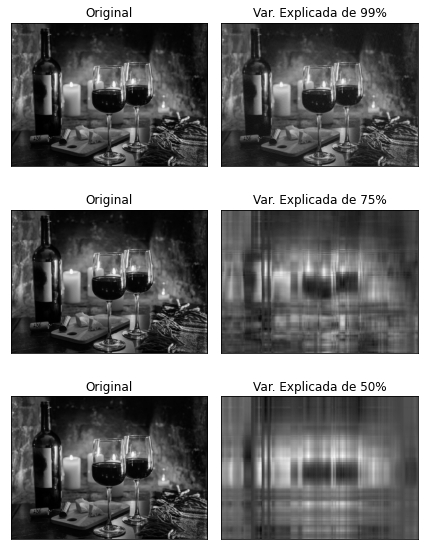

```python
# Plotando a imagem original e algumas versões com diferentes quantidades de autovetores
img_1 = pca_with_var_exp(X_img_gray, var_exp=0.99)
img_2 = pca_with_var_exp(X_img_gray, var_exp=0.75)
img_3 = pca_with_var_exp(X_img_gray, var_exp=0.50)

show_imgs(img_1, img_2, img_3)
```

```python
#lendo a imagem 02
X_img_gray = plt.imread('imgs\img02.jpg')
X_img_gray.shape
```

```
(662, 999)
```

[figure not shown]

```python
plt.imshow(X_img_gray, cmap="gray");
```

```python
#calculando as médias por coluna de X (considerando X composto pelos pixels da imagem)
X_mean = np.mean(X_img_gray, axis=0)
X_mean[:10] #mostrando os primeiros 10
```

```
array([165.25075529, 165.4592145 , 165.59969789, 165.60120846,
       165.71903323, 165.87613293, 165.83081571, 165.63444109,
       165.61782477, 165.86555891])
```

```python
#gerando matriz auxiliar para o cálculo da Matriz de Covariância
M_aux = X_img_gray - X_mean
M_aux[:10] #mostrando os primeiros 10
```

```
array([[-29.25075529, -29.4592145 , -29.59969789, ...,   5.9652568 ,
          6.55891239,   6.59516616],
       [-29.25075529, -29.4592145 , -29.59969789, ...,   6.9652568 ,
          7.55891239,   7.59516616],
       [-28.25075529, -28.4592145 , -28.59969789, ...,   6.9652568 ,
          7.55891239,   7.59516616],
       ...,
       [-26.25075529, -26.4592145 , -26.59969789, ...,   9.9652568 ,
         10.55891239,  10.59516616],
       [-24.25075529, -24.4592145 , -24.59969789, ...,   9.9652568 ,
         10.55891239,  10.59516616],
       [-24.25075529, -24.4592145 , -24.59969789, ...,   9.9652568 ,
         10.55891239,  10.59516616]])
```

```python
#calculando a Matriz de Covariância relativa à imagem
M_cov = M_aux.T.dot(M_aux) / (X_img_gray.shape[0] - 1)
M_cov[:10] #mostrando os primeiros 10
```

```
array([[708.35760155, 681.65018214, 650.9083966 , ..., 187.05178915,
        171.31131536, 176.25082842],
       [681.65018214, 684.68441572, 656.32177283, ..., 194.82970963,
        178.6125709 , 182.99081772],
       [650.9083966 , 656.32177283, 674.16780626, ..., 203.63420113,
        187.49453588, 191.15473671],
       ...,
       [606.8134384 , 614.88975781, 628.68249151, ..., 234.95069267,
        220.55634373, 223.64140664],
       [594.90535717, 594.42084912, 594.341488  , ..., 243.27199702,
        229.28229223, 233.72227377],
       [585.63739368, 582.45668698, 590.3152392 , ..., 230.64764318,
        215.04577428, 217.99550713]])
```

```python
#autovalores da matriz de covariância
# determinando auto-valores e auto-vetores
autoval, autovet = np.linalg.eig(M_cov)
autoval[:10] #mostrando os primeiros 10
```

```
array([530741.91246328+0.j, 325207.62248855+0.j, 121733.77747444+0.j,
        85071.44605343+0.j,  55015.3068675 +0.j,  52351.82005846+0.j,
        37716.85958248+0.j,  31491.19645775+0.j,  29310.05327382+0.j,
        25076.83331047+0.j])
```

```python
autovet[:10] #mostrando os primeiros 10
```

```
array([[ 1.15386830e-02+0.j        , -3.24678752e-02+0.j        ,
        -1.58787173e-02+0.j        , ...,  9.83814162e-04-0.00120627j,
         9.83814162e-04+0.00120627j,  2.35272195e-03+0.j        ],
       [ 1.15612500e-02+0.j        , -3.22529156e-02+0.j        ,
        -1.59996860e-02+0.j        , ..., -1.42840010e-03-0.00151082j,
        -1.42840010e-03+0.00151082j, -6.00842851e-04+0.j        ],
       [ 1.15143604e-02+0.j        , -3.20637568e-02+0.j        ,
        -1.64771711e-02+0.j        , ...,  1.79888725e-03-0.00127332j,
         1.79888725e-03+0.00127332j, -2.64008608e-06+0.j        ],
       ...,
       [ 1.13104986e-02+0.j        , -3.15948344e-02+0.j        ,
        -1.70168914e-02+0.j        , ..., -9.98622700e-03-0.00400787j,
        -9.98622700e-03+0.00400787j,  4.47630833e-04+0.j        ],
       [ 1.18293829e-02+0.j        , -3.14190493e-02+0.j        ,
        -1.76467292e-02+0.j        , ..., -1.47220559e-02-0.00500525j,
        -1.47220559e-02+0.00500525j,  1.61644706e-02+0.j        ],
       [ 1.18568659e-02+0.j        , -3.17470304e-02+0.j        ,
        -1.64597142e-02+0.j        , ..., -1.56375642e-04-0.00094339j,
        -1.56375642e-04+0.00094339j,  1.96094186e-03+0.j        ]])
```

```python
#ordem decrescente
pares_de_autos = [
 (
 np.abs(autoval[i]),
 autovet[:,i]
 ) for i in range(len(autoval))
]
```

```python
# calculando a variância explicada e a variância explicada cumulativa
total = sum(autoval)
var_exp = [
 (i / total)*100 for i in sorted(
 autoval, reverse=True
 )
]
cum_var_exp = np.cumsum(var_exp)
cum_var_exp[:10] #mostrando os primeiros 10
```

```
array([32.11390192+0.j, 51.79142399+0.j, 59.1572387 +0.j, 64.30470494+0.j,
       67.63354732+0.j, 70.80122859+0.j, 73.083384  +0.j, 74.98883969+0.j,
       76.7623197 +0.j, 78.27965788+0.j])
```

```python
# visualizando as informações
x = [
 'PC %s' %i for i in range(
 1,len(autoval)+1
 )
]
df_temp = pd.DataFrame(
 {'auto-valores': autoval,
 'cum_var_exp':cum_var_exp,
 'var_exp':var_exp,
 'Componente':x}
)
df_temp
```

|  | auto-valores | cum_var_exp | var_exp | Componente |
| --- | --- | --- | --- | --- |
| 0 | 5.307419e+05+0.000000e+00j | 32.113902+0.000000j | 3.211390e+01+0.000000e+00j | PC 1 |
| 1 | 3.252076e+05+0.000000e+00j | 51.791424+0.000000j | 1.967752e+01+0.000000e+00j | PC 2 |
| 2 | 1.217338e+05+0.000000e+00j | 59.157239+0.000000j | 7.365815e+00+0.000000e+00j | PC 3 |
| 3 | 8.507145e+04+0.000000e+00j | 64.304705+0.000000j | 5.147466e+00+0.000000e+00j | PC 4 |
| 4 | 5.501531e+04+0.000000e+00j | 67.633547+0.000000j | 3.328842e+00+0.000000e+00j | PC 5 |
| ... | ... | ... | ... | ... |
| 994 | -1.728109e-13-2.275799e-13j | 100.00000+0.00000j | -4.830228e-16-1.022992e-16j | PC 995 |
| 995 | 2.664562e-13+0.000000e+00j | 100.00000+0.00000j | -5.080758e-16+0.000000e+00j | PC 996 |
| 996 | -3.512654e-13+1.678552e-13j | 100.00000+0.00000j | -5.541359e-16+1.741037e-17j | PC 997 |
| 997 | -3.512654e-13-1.678552e-13j | 100.00000+0.00000j | -5.541359e-16-1.741037e-17j | PC 998 |
| 998 | -3.094188e-14+0.000000e+00j | 100.00000+0.00000j | -6.194744e-16+0.000000e+00j | PC 999 |

999 rows × 4 columns

```
(662, 151)
(662, 9)
(662, 2)
```

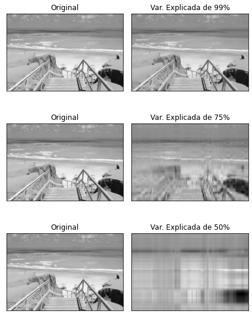

```python
# Plotando a imagem original e algumas versões com diferentes quantidades de autovetores
img_1 = pca_with_var_exp(X_img_gray, var_exp=0.99)
img_2 = pca_with_var_exp(X_img_gray, var_exp=0.75)
img_3 = pca_with_var_exp(X_img_gray, var_exp=0.50)

show_imgs(img_1, img_2, img_3)
```

```python
#lendo a imagem 03
X_img_gray = plt.imread('imgs\img03.jpg')
X_img_gray.shape
```

```
(630, 1200)
```

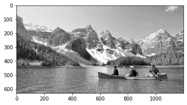

```python
plt.imshow(X_img_gray, cmap="gray");
```

```python
#calculando as médias por coluna de X (considerando X composto pelos pixels da imagem)
X_mean = np.mean(X_img_gray, axis=0)
X_mean[:10] #mostrando os primeiros 10
```

```
array([106.34761905, 106.96666667, 106.86031746, 109.25396825,
       109.2952381 , 109.06507937, 108.9031746 , 108.89206349,
       108.46984127, 108.01269841])
```

```python
#gerando matriz auxiliar para o cálculo da Matriz de Covariância
M_aux = X_img_gray - X_mean
M_aux[:10] #mostrando os primeiros 10
```

```
array([[121.65238095, 121.03333333, 121.13968254, ...,   7.82539683,
          7.11111111,   6.74761905],
       [121.65238095, 121.03333333, 121.13968254, ...,   7.82539683,
          7.11111111,   6.74761905],
       [121.65238095, 121.03333333, 121.13968254, ...,   7.82539683,
          7.11111111,   6.74761905],
       ...,
       [122.65238095, 122.03333333, 122.13968254, ...,   7.82539683,
          7.11111111,   6.74761905],
       [122.65238095, 122.03333333, 122.13968254, ...,   8.82539683,
          8.11111111,   7.74761905],
       [122.65238095, 122.03333333, 122.13968254, ...,   8.82539683,
          8.11111111,   7.74761905]])
```

```python
#calculando a Matriz de Covariância relativa à imagem
M_cov = M_aux.T.dot(M_aux) / (X_img_gray.shape[0] - 1)
M_cov[:10] #mostrando os primeiros 10
```

```
array([[3138.19852373, 2900.16422893, 2774.78949201, ...,  323.48610796,
         257.43296237,  245.64503747],
       [2900.16422893, 3045.68887122, 2878.38961314, ...,  290.84525702,
         227.64334923,  240.74610493],
       [2774.78949201, 2878.38961314, 3067.741984  , ...,  296.06894289,
         249.93676029,  238.17839352],
       ...,
       [2670.30308123, 2628.92485427, 2671.8783809 , ...,  285.56577586,
         230.48719308,  205.02887425],
       [2718.13689151, 2641.16195019, 2706.29148813, ...,  275.78269867,
         231.14131779,  187.01318798],
       [2729.89382996, 2648.5600424 , 2714.54708658, ...,  378.37615767,
         349.648472  ,  291.84893633]])
```

```python
#autovalores da matriz de covariância
# determinando auto-valores e auto-vetores
autoval, autovet = np.linalg.eig(M_cov)
autoval[:10] #mostrando os primeiros 10
```

```
array([1320040.16403934+0.j,  326886.80719116+0.j,  206513.24950434+0.j,
        164789.5801567 +0.j,   95341.72630273+0.j,   81165.76552491+0.j,
         62844.76815817+0.j,   55845.3642681 +0.j,   47250.1772215 +0.j,
         42736.10667895+0.j])
```

```python
autovet[:10] #mostrando os primeiros 10
```

```
array([[-0.03388277+0.j,  0.03794049+0.j,  0.01560529+0.j, ...,
         0.00113048+0.j, -0.00228894+0.j, -0.00055569+0.j],
       [-0.03336447+0.j,  0.03514974+0.j,  0.01563397+0.j, ...,
        -0.00042966+0.j,  0.00015059+0.j,  0.00075256+0.j],
       [-0.03365665+0.j,  0.03329146+0.j,  0.01466505+0.j, ...,
         0.00166736+0.j, -0.00098535+0.j,  0.00014012+0.j],
       ...,
       [-0.03200819+0.j,  0.03810562+0.j,  0.01688776+0.j, ...,
        -0.0011071 +0.j, -0.00115725+0.j,  0.00371258+0.j],
       [-0.0326619 +0.j,  0.04133663+0.j,  0.01706606+0.j, ...,
         0.00197464+0.j, -0.00014013+0.j,  0.00030456+0.j],
       [-0.03393337+0.j,  0.04176423+0.j,  0.01507511+0.j, ...,
        -0.00630172+0.j,  0.00514835+0.j, -0.00313293+0.j]])
```

```python
#ordem decrescente
pares_de_autos = [
 (
 np.abs(autoval[i]),
 autovet[:,i]
 ) for i in range(len(autoval))
]
```

```python
# calculando a variância explicada e a variância explicada cumulativa
total = sum(autoval)
var_exp = [
 (i / total)*100 for i in sorted(
 autoval, reverse=True
 )
]
cum_var_exp = np.cumsum(var_exp)
cum_var_exp[:10] #mostrando os primeiros 10
```

```
array([40.05567207+0.j, 49.9748178 +0.j, 56.24131425+0.j, 61.24173587+0.j,
       64.13481218+0.j, 66.59772913+0.j, 68.50470854+0.j, 70.19929607+0.j,
       71.63306881+0.j, 72.92986532+0.j])
```

```python
# visualizando as informações
x = [
 'PC %s' %i for i in range(
 1,len(autoval)+1
 )
]
df_temp = pd.DataFrame(
 {'auto-valores': autoval,
 'cum_var_exp':cum_var_exp,
 'var_exp':var_exp,
 'Componente':x}
)
df_temp
```

|  | auto-valores | cum_var_exp | var_exp | Componente |
| --- | --- | --- | --- | --- |
| 0 | 1.320040e+06+0.000000e+00j | 40.055672+0.000000j | 4.005567e+01+0.000000e+00j | PC 1 |
| 1 | 3.268868e+05+0.000000e+00j | 49.974818+0.000000j | 9.919146e+00+0.000000e+00j | PC 2 |
| 2 | 2.065132e+05+0.000000e+00j | 56.241314+0.000000j | 6.266496e+00+0.000000e+00j | PC 3 |
| 3 | 1.647896e+05+0.000000e+00j | 61.241736+0.000000j | 5.000422e+00+0.000000e+00j | PC 4 |
| 4 | 9.534173e+04+0.000000e+00j | 64.134812+0.000000j | 2.893076e+00+0.000000e+00j | PC 5 |
| ... | ... | ... | ... | ... |
| 1195 | -9.066415e-13-8.730743e-14j | 100.00000+0.00000j | -7.603710e-16-4.558826e-17j | PC 1196 |
| 1196 | 2.874230e-13+0.000000e+00j | 100.00000+0.00000j | -7.867422e-16+3.632516e-17j | PC 1197 |
| 1197 | 8.944883e-14+0.000000e+00j | 100.00000+0.00000j | -7.867422e-16-3.632516e-17j | PC 1198 |
| 1198 | 7.217410e-13+0.000000e+00j | 100.00000+0.00000j | -8.162371e-16+0.000000e+00j | PC 1199 |
| 1199 | -4.431441e-13+0.000000e+00j | 100.00000+0.00000j | -8.330640e-16+0.000000e+00j | PC 1200 |

1200 rows × 4 columns

```
(630, 287)
(630, 12)
(630, 3)
```

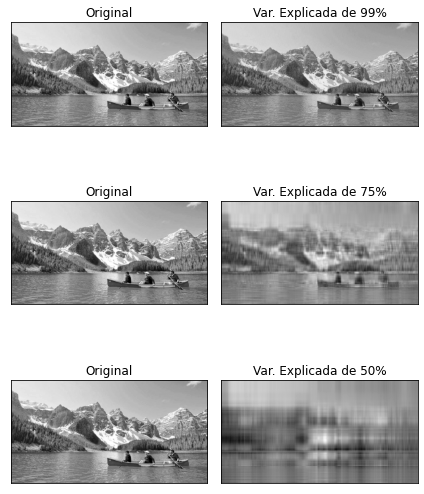

```python
# Plotando a imagem original e algumas versões com diferentes quantidades de autovetores
img_1 = pca_with_var_exp(X_img_gray, var_exp=0.99)
img_2 = pca_with_var_exp(X_img_gray, var_exp=0.75)
img_3 = pca_with_var_exp(X_img_gray, var_exp=0.50)

show_imgs(img_1, img_2, img_3)
```

### 3. Escolha um dos métodos de redução de dimensionalidade do artigo apresentado em sala de aula e faça uma comparação com a técnica PCA. Para basear sua análise, utilize, sempre que possível, os resultados obtidos nessa atividade.

```python
#considerando o mesmo dataset abordado na questão 1
X
```

|  | fixed acidity | volatile acidity | citric acid | residual sugar | chlorides | free sulfur dioxide | total sulfur dioxide | density | pH | sulphates | alcohol |
| --- | --- | --- | --- | --- | --- | --- | --- | --- | --- | --- | --- |
| 0 | 7.4 | 0.700 | 0.00 | 1.9 | 0.076 | 11.0 | 34.0 | 0.99780 | 3.51 | 0.56 | 9.4 |
| 1 | 7.8 | 0.880 | 0.00 | 2.6 | 0.098 | 25.0 | 67.0 | 0.99680 | 3.20 | 0.68 | 9.8 |
| 2 | 7.8 | 0.760 | 0.04 | 2.3 | 0.092 | 15.0 | 54.0 | 0.99700 | 3.26 | 0.65 | 9.8 |
| 3 | 11.2 | 0.280 | 0.56 | 1.9 | 0.075 | 17.0 | 60.0 | 0.99800 | 3.16 | 0.58 | 9.8 |
| 4 | 7.4 | 0.700 | 0.00 | 1.9 | 0.076 | 11.0 | 34.0 | 0.99780 | 3.51 | 0.56 | 9.4 |
| ... | ... | ... | ... | ... | ... | ... | ... | ... | ... | ... | ... |
| 1594 | 6.2 | 0.600 | 0.08 | 2.0 | 0.090 | 32.0 | 44.0 | 0.99490 | 3.45 | 0.58 | 10.5 |
| 1595 | 5.9 | 0.550 | 0.10 | 2.2 | 0.062 | 39.0 | 51.0 | 0.99512 | 3.52 | 0.76 | 11.2 |
| 1596 | 6.3 | 0.510 | 0.13 | 2.3 | 0.076 | 29.0 | 40.0 | 0.99574 | 3.42 | 0.75 | 11.0 |
| 1597 | 5.9 | 0.645 | 0.12 | 2.0 | 0.075 | 32.0 | 44.0 | 0.99547 | 3.57 | 0.71 | 10.2 |
| 1598 | 6.0 | 0.310 | 0.47 | 3.6 | 0.067 | 18.0 | 42.0 | 0.99549 | 3.39 | 0.66 | 11.0 |

1599 rows × 11 columns

```python
y #considerando o mesmo target
```

```
0       5
1       5
2       5
3       6
4       5
       ..
1594    5
1595    6
1596    6
1597    5
1598    6
Name: quality, Length: 1599, dtype: int64
```

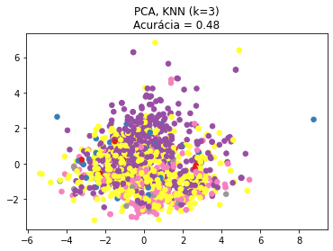

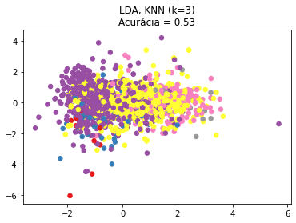

```python
#comparando o LDA com o PCA utilizando a mesma base (vinhos)
# os mesmos parâmetros e o mesmo algoritmo de classificação (KNN)

from sklearn.model_selection import train_test_split
from sklearn.decomposition import PCA
from sklearn.discriminant_analysis import LinearDiscriminantAnalysis
from sklearn.neighbors import KNeighborsClassifier
from sklearn.pipeline import make_pipeline
from sklearn.preprocessing import StandardScaler

n_neighbors = 3
random_state = 0

# Dividindo os datasets de treino e test
X_train, X_test, y_train, y_test = \
    train_test_split(X, y, test_size=0.5, stratify=y,
                     random_state=random_state)

dim = len(X.columns)
n_classes = len(np.unique(y))

# Reduzindo a dimensão para 2 componentes com o PCA
pca = make_pipeline(StandardScaler(),
                    PCA(n_components=2, random_state=random_state))

# Reduzindo a dimensão para 2 componentes com o LDA
lda = make_pipeline(StandardScaler(),
                    LinearDiscriminantAnalysis(n_components=2))

# Usando o KNN como classificador
knn = KNeighborsClassifier(n_neighbors=n_neighbors)

# lista de métodos para serem comparados
dim_reduction_methods = [('PCA', pca), ('LDA', lda)]

# treinando os modelos, testando e gerando os gráficos para comparação
for i, (name, model) in enumerate(dim_reduction_methods):
    plt.figure()
    model.fit(X_train, y_train)
    knn.fit(model.transform(X_train), y_train)
    acc_knn = knn.score(model.transform(X_test), y_test)
    X_embedded = model.transform(X)
    plt.scatter(X_embedded[:, 0], X_embedded[:, 1], c=y, s=30, cmap='Set1')
    plt.title("{}, KNN (k={})\nAcurácia = {:.2f}".format(name,
                                                              n_neighbors,
                                                              acc_knn))
plt.show()
```

# **Referências**

- Mitchell, Tom. Machine learning. McGraw-Hill, 1997.
- Carvalho, André, et al. Inteligência Artificial–uma abordagem de aprendizado de máquina. Rio de Janeiro: LTC, 2011.
- Bruce, Andrew, and Peter Bruce. Estatística Prática para Cientistas de Dados. Alta Books, 2019.
- https://en.wikipedia.org/wiki/Principal_component_analysis
- https://en.wikipedia.org/wiki/Dimensionality_reduction
- Ghodsi, Ali. Dimensionality Reduction A Short Tutorial. 2006.
- R.A. Johnson. Applied Multivariate Statistical Analysis. Prentice Hall, 1992.
- ANOWAR, Farzana, et al. Conceptual and empirical comparison of dimensionality reduction algorithms (PCA, KPCA, LDA, MDS, SVD, LLE, ISOMAP, LE, ICA, t-SNE). Computer Science Review, v. 40, p. 100378, 2021.
- https://en.wikipedia.org/wiki/Linear_discriminant_analysis
- https://scikit-learn.org/stable/modules/generated/sklearn.discriminant_analysis.LinearDiscriminantAnalysis.html
- https://leandrocl2005.github.io/pca_na_mao_e_no_python/
- https://scikit-learn.org/stable/auto_examples/neighbors/plot_nca_dim_reduction.html#sphx-glr-auto-examples-neighbors-plot-nca-dim-reduction-py

```python
#%load_ext notexbook
#%texify
```